# Gathering Data

```python
# Importing necessary libraries
import tweepy
from tweepy import OAuthHandler
import json
from timeit import default_timer as timer
import requests
import pandas as pd
import numpy as np
import re
```

```python
# Accessing the account through developer tokens
import tweepy

consumer_key = 'HIDDEN'
consumer_secret = 'HIDDEN'
access_token = 'HIDDEN'
access_secret = 'HIDDEN'

auth = tweepy.OAuthHandler(consumer_key, consumer_secret)
auth.set_access_token(access_token, access_secret)

api = tweepy.API(auth)
```

```python
# Rmoving the Time limiter.
api = tweepy.API(auth_handler=auth, wait_on_rate_limit=True, wait_on_rate_limit_notify=True)
```

```python
# Reading the twitter archive for accessing the tweets Id
df1 = pd.read_csv('twitter-archive-enhanced.csv')
```

```python
# Grabbing all the tweet Ids into single expression
tweet_ids = df1['tweet_id'].values
```

```python
# Writing a loop to write all the values for tweet ids into json.txt file
count = 0
fails_dict = {}
start = timer()

with open('tweet_json.txt', 'w') as outfile:

    for tweet_id in tweet_ids:
        count += 1
        print(str(count) + ": " + str(tweet_id))
        try:
            tweet = api.get_status(tweet_id, tweet_mode='extended')
            print("Success")
            json.dump(tweet._json, outfile)
            outfile.write('\n')
        except tweepy.TweepError as e:
            print("Fail")
            fails_dict[tweet_id] = e
            pass
end = timer()
print(end - start)
print(fails_dict)
```

[output not shown]

[output cut: 4659 more lines]

[output not shown]

```python
# Appending all the information extracted from json.text into a Dataframe
tweet_api = pd.DataFrame(columns = ['tweet_id','favorite_count','retweet_count'])
with open ('tweet_json.txt') as file:
    for line in file:
        status = json.loads(line)
        tweet_id = status['id']
        favorite_count = status['favorite_count']
        retweet_count = status['retweet_count']
        tweet_api = tweet_api.append(pd.DataFrame([[tweet_id,favorite_count,retweet_count]],
                                                 columns = ['tweet_id','favorite_count','retweet_count']))
tweet_api = tweet_api.reset_index(drop = True)
tweet_api
```

|  | tweet_id | favorite_count | retweet_count |
| --- | --- | --- | --- |
| 0 | 892420643555336193 | 34975 | 7340 |
| 1 | 892177421306343426 | 30277 | 5475 |
| 2 | 891815181378084864 | 22781 | 3621 |
| 3 | 891689557279858688 | 38240 | 7529 |
| 4 | 891327558926688256 | 36523 | 8107 |
| ... | ... | ... | ... |
| 2326 | 666049248165822465 | 93 | 38 |
| 2327 | 666044226329800704 | 259 | 122 |
| 2328 | 666033412701032449 | 107 | 39 |
| 2329 | 666029285002620928 | 117 | 41 |
| 2330 | 666020888022790149 | 2342 | 443 |

2331 rows × 3 columns

```python
# Saving the dataframe as csv
tweet_api.to_csv('tweet_api.csv')
```

```python
# Reading the Csv File for Future Uses
tweet_api = pd.read_csv('tweet_api.csv')
```

# Twitter_archive

### 1. Assessing The Data

```python
# Reading the twitter archive csv
twitter_archive_enhanced = pd.read_csv('twitter-archive-enhanced.csv')
```

```python
# checking the info
twitter_archive_enhanced.info()
```

```
<class 'pandas.core.frame.DataFrame'>
RangeIndex: 2356 entries, 0 to 2355
Data columns (total 17 columns):
 #   Column                      Non-Null Count  Dtype
---  ------                      --------------  -----
 0   tweet_id                    2356 non-null   int64
 1   in_reply_to_status_id       78 non-null     float64
 2   in_reply_to_user_id         78 non-null     float64
 3   timestamp                   2356 non-null   object
 4   source                      2356 non-null   object
 5   text                        2356 non-null   object
 6   retweeted_status_id         181 non-null    float64
 7   retweeted_status_user_id    181 non-null    float64
 8   retweeted_status_timestamp  181 non-null    object
 9   expanded_urls               2297 non-null   object
 10  rating_numerator            2356 non-null   int64
 11  rating_denominator          2356 non-null   int64
 12  name                        2356 non-null   object
 13  doggo                       2356 non-null   object
 14  floofer                     2356 non-null   object
 15  pupper                      2356 non-null   object
 16  puppo                       2356 non-null   object
dtypes: float64(4), int64(3), object(10)
memory usage: 313.0+ KB
```

```python
twitter_archive_enhanced.head()
```

|  | tweet_id | in_reply_to_status_id | in_reply_to_user_id | timestamp | source | text | retweeted_status_id | retweeted_status_user_id | retweeted_status_timestamp | expanded_urls | rating_numerator | rating_denominator | name | doggo | floofer | pupper | puppo |
| --- | --- | --- | --- | --- | --- | --- | --- | --- | --- | --- | --- | --- | --- | --- | --- | --- | --- |
| 0 | 892420643555336193 | NaN | NaN | 2017-08-01 16:23:56 +0000 | <a href="http://twitter.com/download/iphone" r... | This is Phineas. He's a mystical boy. Only eve... | NaN | NaN | NaN | https://twitter.com/dog_rates/status/892420643... | 13 | 10 | Phineas | None | None | None | None |
| 1 | 892177421306343426 | NaN | NaN | 2017-08-01 00:17:27 +0000 | <a href="http://twitter.com/download/iphone" r... | This is Tilly. She's just checking pup on you.... | NaN | NaN | NaN | https://twitter.com/dog_rates/status/892177421... | 13 | 10 | Tilly | None | None | None | None |
| 2 | 891815181378084864 | NaN | NaN | 2017-07-31 00:18:03 +0000 | <a href="http://twitter.com/download/iphone" r... | This is Archie. He is a rare Norwegian Pouncin... | NaN | NaN | NaN | https://twitter.com/dog_rates/status/891815181... | 12 | 10 | Archie | None | None | None | None |
| 3 | 891689557279858688 | NaN | NaN | 2017-07-30 15:58:51 +0000 | <a href="http://twitter.com/download/iphone" r... | This is Darla. She commenced a snooze mid meal... | NaN | NaN | NaN | https://twitter.com/dog_rates/status/891689557... | 13 | 10 | Darla | None | None | None | None |
| 4 | 891327558926688256 | NaN | NaN | 2017-07-29 16:00:24 +0000 | <a href="http://twitter.com/download/iphone" r... | This is Franklin. He would like you to stop ca... | NaN | NaN | NaN | https://twitter.com/dog_rates/status/891327558... | 12 | 10 | Franklin | None | None | None | None |

```python
# Evaluating the values for each stage
twitter_archive_enhanced['doggo'].value_counts()
```

```
None     2259
doggo      97
Name: doggo, dtype: int64
```

```python
# Checking the source
twitter_archive_enhanced['source']
```

```
0       <a href="http://twitter.com/download/iphone" r...
1       <a href="http://twitter.com/download/iphone" r...
2       <a href="http://twitter.com/download/iphone" r...
3       <a href="http://twitter.com/download/iphone" r...
4       <a href="http://twitter.com/download/iphone" r...
                              ...
2351    <a href="http://twitter.com/download/iphone" r...
2352    <a href="http://twitter.com/download/iphone" r...
2353    <a href="http://twitter.com/download/iphone" r...
2354    <a href="http://twitter.com/download/iphone" r...
2355    <a href="http://twitter.com/download/iphone" r...
Name: source, Length: 2356, dtype: object
```

```python
# Reading the text file as list to disclose full text
twitter_archive_enhanced['text'].to_list()
```

```
["This is Phineas. He's a mystical boy. Only ever appears in the hole of a donut. 13/10 https://t.co/MgUWQ76dJU",
 "This is Tilly. She's just checking pup on you. Hopes you're doing ok. If not, she's available for pats, snugs, boops, the whole bit. 13/10 https://t.co/0Xxu71qeIV",
 'This is Archie. He is a rare Norwegian Pouncing Corgo. Lives in the tall grass. You never know when one may strike. 12/10 https://t.co/wUnZnhtVJB',
 'This is Darla. She commenced a snooze mid meal. 13/10 happens to the best of us https://t.co/tD36da7qLQ',
 'This is Franklin. He would like you to stop calling him "cute." He is a very fierce shark and should be respected as such. 12/10 #BarkWeek https://t.co/AtUZn91f7f',
 "Here we have a majestic great white breaching off South Africa's coast. Absolutely h*ckin breathtaking. 13/10 (IG: tucker_marlo) #BarkWeek https://t.co/kQ04fDDRmh",
 'Meet Jax. He enjoys ice cream so much he gets nervous around it. 13/10 help Jax enjoy more things by clicking below\n\nhttps://t.co/Zr4hWfAs1H https://t.co/tVJBRMnhxl',
 "When you watch your owner call another dog a good boy but then they turn back to you and say you're a great boy. 13/10 https://t.co/v0nONBcwxq",
 "This is Zoey. She doesn't want to be one of the scary sharks. Just wants to be a snuggly pettable boatpet. 13/10 #BarkWeek https://t.co/9TwLuAGH0b",
 'This is Cassie. She is a college pup. Studying international doggo communication and stick theory. 14/10 so elegant much sophisticate https://t.co/t1bfwz5S2A',
 'This is Koda. He is a South Australian deckshark. Deceptively deadly. Frighteningly majestic. 13/10 would risk a petting #BarkWeek https://t.co/dVPW0B0Mme',
 'This is Bruno. He is a service shark. Only gets out of the water to assist you. 13/10 terrifyingly good boy https://t.co/u1XPQMl29g',
 "Here's a puppo that seems to be on the fence about something haha no but seriously someone help her. 13/10 https://t.co/BxvuXk0UCm",
 "This is Ted. He does his best. Sometimes that's not enough. But it's ok. 12/10 would assist https://t.co/f8dEDcrKSR",
 "This is Stuart. He's sporting his favorite fanny pack. Secretly filled with bones only. 13/10 puppared puppo #BarkWeek https://t.co/y70o6h3isq",
 "This is Oliver. You're witnessing one of his many brutal attacks. Seems to be playing with his victim. 13/10 fr*ckin frightening #BarkWeek https://t.co/WpHvrQedPb",
 'This is Jim. He found a fren. Taught him how to sit like the good boys. 12/10 for both https://t.co/chxruIOUJN',
 'This is Zeke. He has a new stick. Very proud of it. Would like you to throw it for him without taking it. 13/10 would do my best https://t.co/HTQ77yNQ5K',
 "This is Ralphus. He's powering up. Attempting maximum borkdrive. 13/10 inspirational af https://t.co/YnYAFCTTiK",
 'RT @dog_rates: This is Canela. She attempted some fancy porch pics. They were unsuccessful. 13/10 someone help her https://t.co/cLyzpcUcMX',
 "This is Gerald. He was just told he didn't get the job he interviewed for. A h*ckin injustice. 12/10 didn't want the job anyway https://t.co/DK7iDPfuRX",
 "This is Jeffrey. He has a monopoly on the pool noodles. Currently running a 'boop for two' midweek sale. 13/10 h*ckin strategic https://t.co/PhrUk20Q64",
 "I've yet to rate a Venezuelan Hover Wiener. This is such an honor. 14/10 paw-inspiring af (IG: roxy.thedoxy) https://t.co/20VrLAA8ba",
 'This is Canela. She attempted some fancy porch pics. They were unsuccessful. 13/10 someone help her https://t.co/cLyzpcUcMX',
 'You may not have known you needed to see this today. 13/10 please enjoy (IG: emmylouroo) https://t.co/WZqNqygEyV',
 'This... is a Jubilant Antarctic House Bear. We only rate dogs. Please only send dogs. Thank you... 12/10 would suffocate in floof https://t.co/4Ad1jzJSdp',
 "This is Maya. She's very shy. Rarely leaves her cup. 13/10 would find her an environment to thrive in https://t.co/I6oNy0CgiT",
 "This is Mingus. He's a wonderful father to his smol pup. Confirmed 13/10, but he needs your help\n\nhttps://t.co/bVi0Yr4Cff https://t.co/ISvKOSkd5b",
 "This is Derek. He's late for a dog meeting. 13/10 pet...al to the metal https://t.co/BCoWue0abA",
 'This is Roscoe. Another pupper fallen victim to spontaneous tongue ejections. Get the BlepiPen immediate. 12/10 deep breaths Roscoe https://t.co/RGE08MIJox',
 '@NonWhiteHat @MayhewMayhem omg hello tanner you are a scary good boy 12/10 would pet with extreme caution',
 'This is Waffles. His doggles are pupside down. Unsure how to fix. 13/10 someone assist Waffles https://t.co/xZDA9Qsq1O',
 'RT @Athletics: 12/10 #BATP https://t.co/WxwJmvjfxo',
 'Viewer discretion advised. This is Jimbo. He will rip ur finger right h*ckin off. Other dog clearly an accessory. 12/10 pls pet with caution https://t.co/BuveP0uMF1',
 'This is Maisey. She fell asleep mid-excavation. Happens to the best of us. 13/10 would pat noggin approvingly https://t.co/tp1kQ8i9JF',
 'I have a new hero and his name is Howard. 14/10 https://t.co/gzLHboL7Sk',
 'RT @dog_rates: This is Lilly. She just parallel barked. Kindly requests a reward now. 13/10 would pet so well https://t.co/SATN4If5H5',
 'Here we have a corgi undercover as a malamute. Pawbably doing important investigative work. Zero control over tongue happenings. 13/10 https://t.co/44ItaMubBf',
 "This is Earl. He found a hat. Nervous about what you think of it. 12/10 it's delightful, Earl https://t.co/MYJvdlNRVa",
 "This is Lola. It's her first time outside. Must test the earth and taste the atmosphere. 13/10 you're doing great Lola https://t.co/74TKAUsLkO",
```

[output cut: 946 more lines]

```
 "Meet Winston. He's pupset because I forgot to mention that it's Canada Day today. 11/10 please forgive me Winston https://t.co/xEY8dbJxnF",
 "This is Dietrich. He hops at random. Other doggos don't understand him. It upsets him greatly. 8/10 would comfort https://t.co/U8cSRz8wzC",
 'What jokester sent in a pic without a dog in it? This is not @rock_rates. This is @dog_rates. Thank you ...10/10 https://t.co/nDPaYHrtNX',
 'Say hello to Divine Doggo. Must be magical af. 13/10 would be an honor to pet https://t.co/BbcABzohKb',
 '#BarkWeek is getting rather heckin terrifying over here. Doin me quite the spooken. 13/10 (vid by @corgi_zero) https://t.co/eA7k1ZQslA',
 "Meet Tripp. He's being eaten by a sherk and doesn't even care. Unfazed af. 11/10 keep doin you Tripp https://t.co/gGxjthmG1c",
 'That is Quizno. This is his beach. He does not tolerate human shenanigans on his beach. 10/10 reclaim ur land doggo https://t.co/vdr7DaRSa7',
 "This is one of the most reckless puppers I've ever seen. How she got a license in the first place is beyond me. 6/10 https://t.co/z5bAdtn9kd",
 'This is Cora. She rings a bell for treats. 12/10 precious af (vid by @skyehellenkamp) https://t.co/uUncaAGH18',
 '"So... we meat again" (I\'m so sorry for that pun I couldn\'t resist pls don\'t unfollow) 10/10 https://t.co/XFBrrqapZa',
 'SWIM AWAY PUPPER SWIM AWAY 13/10 #BarkWeek  https://t.co/QGGhZoTcwy',
 'This is Duke. He permanently looks like he just tripped over something. 11/10 https://t.co/1sNtG7GgiO',
 "This sherk must've leapt out of the water and into the canoe, trapping the human. Won't even help paddle smh. 7/10 https://t.co/KubWEqOIgO",
 "Stop what you're doing and watch this heckin masterpiece right here. Both 13/10 https://t.co/3BOVI2WZoH",
 ...]
```

```python
# Quick analysis of data
twitter_archive_enhanced.describe()
```

|  | tweet_id | in_reply_to_status_id | in_reply_to_user_id | retweeted_status_id | retweeted_status_user_id | rating_numerator | rating_denominator |
| --- | --- | --- | --- | --- | --- | --- | --- |
| count | 2.356000e+03 | 7.800000e+01 | 7.800000e+01 | 1.810000e+02 | 1.810000e+02 | 2356.000000 | 2356.000000 |
| mean | 7.427716e+17 | 7.455079e+17 | 2.014171e+16 | 7.720400e+17 | 1.241698e+16 | 13.126486 | 10.455433 |
| std | 6.856705e+16 | 7.582492e+16 | 1.252797e+17 | 6.236928e+16 | 9.599254e+16 | 45.876648 | 6.745237 |
| min | 6.660209e+17 | 6.658147e+17 | 1.185634e+07 | 6.661041e+17 | 7.832140e+05 | 0.000000 | 0.000000 |
| 25% | 6.783989e+17 | 6.757419e+17 | 3.086374e+08 | 7.186315e+17 | 4.196984e+09 | 10.000000 | 10.000000 |
| 50% | 7.196279e+17 | 7.038708e+17 | 4.196984e+09 | 7.804657e+17 | 4.196984e+09 | 11.000000 | 10.000000 |
| 75% | 7.993373e+17 | 8.257804e+17 | 4.196984e+09 | 8.203146e+17 | 4.196984e+09 | 12.000000 | 10.000000 |
| max | 8.924206e+17 | 8.862664e+17 | 8.405479e+17 | 8.874740e+17 | 7.874618e+17 | 1776.000000 | 170.000000 |

```python
# Distinct value for source
twitter_archive_enhanced['source'].value_counts()
```

```
<a href="http://twitter.com/download/iphone" rel="nofollow">Twitter for iPhone</a>     2221
<a href="http://vine.co" rel="nofollow">Vine - Make a Scene</a>                          91
<a href="http://twitter.com" rel="nofollow">Twitter Web Client</a>                       33
<a href="https://about.twitter.com/products/tweetdeck" rel="nofollow">TweetDeck</a>      11
Name: source, dtype: int64
```

```python
# Checking where the denominator is not equal to 10
twitter_archive_enhanced.query('rating_denominator != 10')
```

|  | tweet_id | in_reply_to_status_id | in_reply_to_user_id | timestamp | source | text | retweeted_status_id | retweeted_status_user_id | retweeted_status_timestamp | expanded_urls | rating_numerator | rating_denominator | name | doggo | floofer | pupper | puppo |
| --- | --- | --- | --- | --- | --- | --- | --- | --- | --- | --- | --- | --- | --- | --- | --- | --- | --- |
| 313 | 835246439529840640 | 8.352460e+17 | 2.625958e+07 | 2017-02-24 21:54:03 +0000 | <a href="http://twitter.com/download/iphone" r... | @jonnysun @Lin_Manuel ok jomny I know you're e... | NaN | NaN | NaN | NaN | 960 | 0 | None | None | None | None | None |
| 342 | 832088576586297345 | 8.320875e+17 | 3.058208e+07 | 2017-02-16 04:45:50 +0000 | <a href="http://twitter.com/download/iphone" r... | @docmisterio account started on 11/15/15 | NaN | NaN | NaN | NaN | 11 | 15 | None | None | None | None | None |
| 433 | 820690176645140481 | NaN | NaN | 2017-01-15 17:52:40 +0000 | <a href="http://twitter.com/download/iphone" r... | The floofs have been released I repeat the flo... | NaN | NaN | NaN | https://twitter.com/dog_rates/status/820690176... | 84 | 70 | None | None | None | None | None |
| 516 | 810984652412424192 | NaN | NaN | 2016-12-19 23:06:23 +0000 | <a href="http://twitter.com/download/iphone" r... | Meet Sam. She smiles 24/7 &amp; secretly aspir... | NaN | NaN | NaN | https://www.gofundme.com/sams-smile,https://tw... | 24 | 7 | Sam | None | None | None | None |
| 784 | 775096608509886464 | NaN | NaN | 2016-09-11 22:20:06 +0000 | <a href="http://twitter.com/download/iphone" r... | RT @dog_rates: After so many requests, this is... | 7.403732e+17 | 4.196984e+09 | 2016-06-08 02:41:38 +0000 | https://twitter.com/dog_rates/status/740373189... | 9 | 11 | None | None | None | None | None |
| 902 | 758467244762497024 | NaN | NaN | 2016-07-28 01:00:57 +0000 | <a href="http://twitter.com/download/iphone" r... | Why does this never happen at my front door...... | NaN | NaN | NaN | https://twitter.com/dog_rates/status/758467244... | 165 | 150 | None | None | None | None | None |
| 1068 | 740373189193256964 | NaN | NaN | 2016-06-08 02:41:38 +0000 | <a href="http://twitter.com/download/iphone" r... | After so many requests, this is Bretagne. She ... | NaN | NaN | NaN | https://twitter.com/dog_rates/status/740373189... | 9 | 11 | None | None | None | None | None |
| 1120 | 731156023742988288 | NaN | NaN | 2016-05-13 16:15:54 +0000 | <a href="http://twitter.com/download/iphone" r... | Say hello to this unbelievably well behaved sq... | NaN | NaN | NaN | https://twitter.com/dog_rates/status/731156023... | 204 | 170 | this | None | None | None | None |
| 1165 | 722974582966214656 | NaN | NaN | 2016-04-21 02:25:47 +0000 | <a href="http://twitter.com/download/iphone" r... | Happy 4/20 from the squad! 13/10 for all https... | NaN | NaN | NaN | https://twitter.com/dog_rates/status/722974582... | 4 | 20 | None | None | None | None | None |
| 1202 | 716439118184652801 | NaN | NaN | 2016-04-03 01:36:11 +0000 | <a href="http://twitter.com/download/iphone" r... | This is Bluebert. He just saw that both #Final... | NaN | NaN | NaN | https://twitter.com/dog_rates/status/716439118... | 50 | 50 | Bluebert | None | None | None | None |
| 1228 | 713900603437621249 | NaN | NaN | 2016-03-27 01:29:02 +0000 | <a href="http://twitter.com/download/iphone" r... | Happy Saturday here's 9 puppers on a bench. 99... | NaN | NaN | NaN | https://twitter.com/dog_rates/status/713900603... | 99 | 90 | None | None | None | None | None |
| 1254 | 710658690886586372 | NaN | NaN | 2016-03-18 02:46:49 +0000 | <a href="http://twitter.com/download/iphone" r... | Here's a brigade of puppers. All look very pre... | NaN | NaN | NaN | https://twitter.com/dog_rates/status/710658690... | 80 | 80 | None | None | None | None | None |
| 1274 | 709198395643068416 | NaN | NaN | 2016-03-14 02:04:08 +0000 | <a href="http://twitter.com/download/iphone" r... | From left to right:\nCletus, Jerome, Alejandro... | NaN | NaN | NaN | https://twitter.com/dog_rates/status/709198395... | 45 | 50 | None | None | None | None | None |
| 1351 | 704054845121142784 | NaN | NaN | 2016-02-28 21:25:30 +0000 | <a href="http://twitter.com/download/iphone" r... | Here is a whole flock of puppers. 60/50 I'll ... | NaN | NaN | NaN | https://twitter.com/dog_rates/status/704054845... | 60 | 50 | a | None | None | None | None |
| 1433 | 697463031882764288 | NaN | NaN | 2016-02-10 16:51:59 +0000 | <a href="http://twitter.com/download/iphone" r... | Happy Wednesday here's a bucket of pups. 44/40... | NaN | NaN | NaN | https://twitter.com/dog_rates/status/697463031... | 44 | 40 | None | None | None | None | None |
| 1598 | 686035780142297088 | 6.860340e+17 | 4.196984e+09 | 2016-01-10 04:04:10 +0000 | <a href="http://twitter.com/download/iphone" r... | Yes I do realize a rating of 4/20 would've bee... | NaN | NaN | NaN | NaN | 4 | 20 | None | None | None | None | None |
| 1634 | 684225744407494656 | 6.842229e+17 | 4.196984e+09 | 2016-01-05 04:11:44 +0000 | <a href="http://twitter.com/download/iphone" r... | Two sneaky puppers were not initially seen, mo... | NaN | NaN | NaN | https://twitter.com/dog_rates/status/684225744... | 143 | 130 | None | None | None | None | None |
| 1635 | 684222868335505415 | NaN | NaN | 2016-01-05 04:00:18 +0000 | <a href="http://twitter.com/download/iphone" r... | Someone help the girl is being mugged. Several... | NaN | NaN | NaN | https://twitter.com/dog_rates/status/684222868... | 121 | 110 | None | None | None | None | None |
| 1662 | 682962037429899265 | NaN | NaN | 2016-01-01 16:30:13 +0000 | <a href="http://twitter.com/download/iphone" r... | This is Darrel. He just robbed a 7/11 and is i... | NaN | NaN | NaN | https://twitter.com/dog_rates/status/682962037... | 7 | 11 | Darrel | None | None | None | None |
| 1663 | 682808988178739200 | 6.827884e+17 | 4.196984e+09 | 2016-01-01 06:22:03 +0000 | <a href="http://twitter.com/download/iphone" r... | I'm aware that I could've said 20/16, but here... | NaN | NaN | NaN | NaN | 20 | 16 | None | None | None | None | None |
| 1779 | 677716515794329600 | NaN | NaN | 2015-12-18 05:06:23 +0000 | <a href="http://twitter.com/download/iphone" r... | IT'S PUPPERGEDDON. Total of 144/120 ...I think... | NaN | NaN | NaN | https://twitter.com/dog_rates/status/677716515... | 144 | 120 | None | None | None | None | None |
| 1843 | 675853064436391936 | NaN | NaN | 2015-12-13 01:41:41 +0000 | <a href="http://twitter.com/download/iphone" r... | Here we have an entire platoon of puppers. Tot... | NaN | NaN | NaN | https://twitter.com/dog_rates/status/675853064... | 88 | 80 | None | None | None | None | None |
| 2335 | 666287406224695296 | NaN | NaN | 2015-11-16 16:11:11 +0000 | <a href="http://twitter.com/download/iphone" r... | This is an Albanian 3 1/2 legged Episcopalian... | NaN | NaN | NaN | https://twitter.com/dog_rates/status/666287406... | 1 | 2 | an | None | None | None | None |

```python
# Checking where the numerator is less than 10
twitter_archive_enhanced.query('rating_numerator < 10')
```

|  | tweet_id | in_reply_to_status_id | in_reply_to_user_id | timestamp | source | text | retweeted_status_id | retweeted_status_user_id | retweeted_status_timestamp | expanded_urls | rating_numerator | rating_denominator | name | doggo | floofer | pupper | puppo |
| --- | --- | --- | --- | --- | --- | --- | --- | --- | --- | --- | --- | --- | --- | --- | --- | --- | --- |
| 45 | 883482846933004288 | NaN | NaN | 2017-07-08 00:28:19 +0000 | <a href="http://twitter.com/download/iphone" r... | This is Bella. She hopes her smile made you sm... | NaN | NaN | NaN | https://twitter.com/dog_rates/status/883482846... | 5 | 10 | Bella | None | None | None | None |
| 229 | 848212111729840128 | NaN | NaN | 2017-04-01 16:35:01 +0000 | <a href="http://twitter.com/download/iphone" r... | This is Jerry. He's doing a distinguished tong... | NaN | NaN | NaN | https://twitter.com/dog_rates/status/848212111... | 6 | 10 | Jerry | None | None | None | None |
| 315 | 835152434251116546 | NaN | NaN | 2017-02-24 15:40:31 +0000 | <a href="http://twitter.com/download/iphone" r... | When you're so blinded by your systematic plag... | NaN | NaN | NaN | https://twitter.com/dog_rates/status/835152434... | 0 | 10 | None | None | None | None | None |
| 387 | 826598799820865537 | 8.265984e+17 | 4.196984e+09 | 2017-02-01 01:11:25 +0000 | <a href="http://twitter.com/download/iphone" r... | I was going to do 007/10, but the joke wasn't ... | NaN | NaN | NaN | NaN | 7 | 10 | None | None | None | None | None |
| 462 | 817502432452313088 | NaN | NaN | 2017-01-06 22:45:43 +0000 | <a href="http://twitter.com/download/iphone" r... | RT @dog_rates: Meet Herschel. He's slightly bi... | 6.924173e+17 | 4.196984e+09 | 2016-01-27 18:42:06 +0000 | https://twitter.com/dog_rates/status/692417313... | 7 | 10 | Herschel | None | None | pupper | None |
| ... | ... | ... | ... | ... | ... | ... | ... | ... | ... | ... | ... | ... | ... | ... | ... | ... | ... |
| 2351 | 666049248165822465 | NaN | NaN | 2015-11-16 00:24:50 +0000 | <a href="http://twitter.com/download/iphone" r... | Here we have a 1949 1st generation vulpix. Enj... | NaN | NaN | NaN | https://twitter.com/dog_rates/status/666049248... | 5 | 10 | None | None | None | None | None |
| 2352 | 666044226329800704 | NaN | NaN | 2015-11-16 00:04:52 +0000 | <a href="http://twitter.com/download/iphone" r... | This is a purebred Piers Morgan. Loves to Netf... | NaN | NaN | NaN | https://twitter.com/dog_rates/status/666044226... | 6 | 10 | a | None | None | None | None |
| 2353 | 666033412701032449 | NaN | NaN | 2015-11-15 23:21:54 +0000 | <a href="http://twitter.com/download/iphone" r... | Here is a very happy pup. Big fan of well-main... | NaN | NaN | NaN | https://twitter.com/dog_rates/status/666033412... | 9 | 10 | a | None | None | None | None |
| 2354 | 666029285002620928 | NaN | NaN | 2015-11-15 23:05:30 +0000 | <a href="http://twitter.com/download/iphone" r... | This is a western brown Mitsubishi terrier. Up... | NaN | NaN | NaN | https://twitter.com/dog_rates/status/666029285... | 7 | 10 | a | None | None | None | None |
| 2355 | 666020888022790149 | NaN | NaN | 2015-11-15 22:32:08 +0000 | <a href="http://twitter.com/download/iphone" r... | Here we have a Japanese Irish Setter. Lost eye... | NaN | NaN | NaN | https://twitter.com/dog_rates/status/666020888... | 8 | 10 | None | None | None | None | None |

440 rows × 17 columns

## Assessment For Quality ( for twitter archive )

1. Various ratings where denominator is not 10.
2. Various Null values for columns in_reply_to_status_id in_reply_to_user_id retweeted_status_id retweeted_status_user_id
3. Incorrect Data type for tweet Id
4. Renaming Columns with more appropriate name
5. The names are not all correct.
6. The Denominator can't be zero
7. Removal of all the Retweets
8. Non-Inclusion of Float numerators

## Assessment ForTidiness ( for twitter archive )

1. Various stages of dogs is de-classified
2. Timestamp Column needs to be seperated with Time and Date
3. The clarity In source of text must be shown.

### 2. Coding

##### DEFINE (A)

Remove all the retweets from text sections by using str.contains()

##### CODE (A)

```python
twitter_archive_enhanced = twitter_archive_enhanced[twitter_archive_enhanced["text"].str.contains("RT")==False]
```

##### TEST (A)

```python
twitter_archive_enhanced[twitter_archive_enhanced["text"].str.contains("RT")==True]
```

|  | tweet_id | in_reply_to_status_id | in_reply_to_user_id | timestamp | source | text | retweeted_status_id | retweeted_status_user_id | retweeted_status_timestamp | expanded_urls | rating_numerator | rating_denominator | name | doggo | floofer | pupper | puppo |
| --- | --- | --- | --- | --- | --- | --- | --- | --- | --- | --- | --- | --- | --- | --- | --- | --- | --- |

##### DEFINE (B)

Extract Ratings from the text as correct ratings and split them on the basis of delimeter (' *\* ') and make new columns from the both splitted values.

##### CODE (B)

```python
# Extract ratimg from text
twitter_archive_enhanced['ratings'] = twitter_archive_enhanced.text.str.extract('([0-9]*\d\/\d\d)', expand=True)
twitter_archive_enhanced['ratings']
```

```
0       13/10
1       13/10
2       12/10
3       13/10
4       12/10
        ...
2351     5/10
2352     6/10
2353     9/10
2354     7/10
2355     8/10
Name: ratings, Length: 2164, dtype: object
```

```python
new = twitter_archive_enhanced['ratings'].str.split("/", n = 1, expand = True)

# making separate first name column from new data frame
twitter_archive_enhanced['rating_numerator_new']= new[0]

# making separate last name column from new data frame
twitter_archive_enhanced['rating_denominator_new']= new[1]
```

##### TEST (B)

```python
twitter_archive_enhanced.head()
```

|  | tweet_id | in_reply_to_status_id | in_reply_to_user_id | timestamp | source | text | retweeted_status_id | retweeted_status_user_id | retweeted_status_timestamp | expanded_urls | rating_numerator | rating_denominator | name | doggo | floofer | pupper | puppo | ratings | rating_numerator_new | rating_denominator_new |
| --- | --- | --- | --- | --- | --- | --- | --- | --- | --- | --- | --- | --- | --- | --- | --- | --- | --- | --- | --- | --- |
| 0 | 892420643555336193 | NaN | NaN | 2017-08-01 16:23:56 +0000 | <a href="http://twitter.com/download/iphone" r... | This is Phineas. He's a mystical boy. Only eve... | NaN | NaN | NaN | https://twitter.com/dog_rates/status/892420643... | 13 | 10 | Phineas | None | None | None | None | 13/10 | 13 | 10 |
| 1 | 892177421306343426 | NaN | NaN | 2017-08-01 00:17:27 +0000 | <a href="http://twitter.com/download/iphone" r... | This is Tilly. She's just checking pup on you.... | NaN | NaN | NaN | https://twitter.com/dog_rates/status/892177421... | 13 | 10 | Tilly | None | None | None | None | 13/10 | 13 | 10 |
| 2 | 891815181378084864 | NaN | NaN | 2017-07-31 00:18:03 +0000 | <a href="http://twitter.com/download/iphone" r... | This is Archie. He is a rare Norwegian Pouncin... | NaN | NaN | NaN | https://twitter.com/dog_rates/status/891815181... | 12 | 10 | Archie | None | None | None | None | 12/10 | 12 | 10 |
| 3 | 891689557279858688 | NaN | NaN | 2017-07-30 15:58:51 +0000 | <a href="http://twitter.com/download/iphone" r... | This is Darla. She commenced a snooze mid meal... | NaN | NaN | NaN | https://twitter.com/dog_rates/status/891689557... | 13 | 10 | Darla | None | None | None | None | 13/10 | 13 | 10 |
| 4 | 891327558926688256 | NaN | NaN | 2017-07-29 16:00:24 +0000 | <a href="http://twitter.com/download/iphone" r... | This is Franklin. He would like you to stop ca... | NaN | NaN | NaN | https://twitter.com/dog_rates/status/891327558... | 12 | 10 | Franklin | None | None | None | None | 12/10 | 12 | 10 |

##### DEFINE (C)

As per we rate doges guidelines, they rate dog on the base of 10, so there is no chance that any values could be else than 10. We will turn all the non 10 values to 10

##### CODE(C)

```python
twitter_archive_enhanced.loc[(twitter_archive_enhanced.rating_denominator != 10 ),'rating_denominator']=10
```

##### TEST (C)

```python
twitter_archive_enhanced['rating_denominator'].value_counts()
```

```
10    2164
Name: rating_denominator, dtype: int64
```

##### DEFINE (D)

Extracting some float ratings from the text using the regex extract function

##### CODE (D)

```python
# extracting correcr numerator values from text
twitter_archive_enhanced.rating_numerator_new = twitter_archive_enhanced.text.str.extract('((?:\d+\.)?\d+)\/(\d+)', expand=True)
```

##### TEST (D)

```python
twitter_archive_enhanced['rating_numerator_new'].value_counts()
```

```
12       497
10       437
11       424
13       306
9        156
8         98
7         53
14        43
5         34
6         32
3         19
4         17
2          9
1          8
420        2
```

[output cut: 29 more lines]

##### DEFINE (E)

After assessing the data without program I've found that some of the names were incorrect. So I will extract all the names from the text section and create a new series for it.

##### CODE (E)

```python
#Extracting dog_name from the text column
text_dog_name = []
for text in twitter_archive_enhanced.text:
  name_search = re.search('([Tt]his is\s\w+)', text) or re.search('([Mm]eet\s\w+)', text)
  if name_search:
    # split the string and choosing last word
    name = name_search.group().split()[-1]
    text_dog_name.append(name)

text_dog_name
```

```
['Phineas',
 'Tilly',
 'Archie',
 'Darla',
 'Franklin',
 'Jax',
 'Zoey',
 'Cassie',
 'Koda',
 'Bruno',
 'Ted',
 'Stuart',
 'Oliver',
 'Jim',
 'Zeke',
 'Ralphus',
 'Gerald',
 'Jeffrey',
 'such',
 'Canela',
 'Maya',
 'Mingus',
 'Derek',
 'Roscoe',
 'Waffles',
 'Jimbo',
 'Maisey',
 'Earl',
 'Lola',
 'Kevin',
 'Yogi',
 'Noah',
 'Bella',
 'Grizzwald',
 'Rusty',
 'Gus',
 'Stanley',
 'Alfy',
 'Koko',
 'Rey',
```

[output cut: 946 more lines]

```
 'Sweets',
 'how',
 'Sadie',
 'Jiminy',
 'Buddy',
 'Sebastian',
 'Griffin',
 'Banjo',
 'Brandy',
 'Larry',
 'Lulu',
 'Darrel',
 'Taco',
 'Joey',
 ...]
```

```python
#adding text_dog_name column in master_clean data frame
twitter_archive_enhanced['text_dog_name'] = pd.Series(text_dog_name)
```

##### TEST (E)

```python
twitter_archive_enhanced.head(1)
```

|  | tweet_id | in_reply_to_status_id | in_reply_to_user_id | timestamp | source | text | retweeted_status_id | retweeted_status_user_id | retweeted_status_timestamp | expanded_urls | ... | rating_denominator | name | doggo | floofer | pupper | puppo | ratings | rating_numerator_new | rating_denominator_new | text_dog_name |
| --- | --- | --- | --- | --- | --- | --- | --- | --- | --- | --- | --- | --- | --- | --- | --- | --- | --- | --- | --- | --- | --- |
| 0 | 892420643555336193 | NaN | NaN | 2017-08-01 16:23:56 +0000 | <a href="http://twitter.com/download/iphone" r... | This is Phineas. He's a mystical boy. Only eve... | NaN | NaN | NaN | https://twitter.com/dog_rates/status/892420643... | ... | 10 | Phineas | None | None | None | None | 13/10 | 13 | 10 | Phineas |

1 rows × 21 columns

##### DEFINE (F)

As we know that the doggo, floofer, pupper and puppo are the four stages of the dogs. But somehow they are all differently categorised in the different columns so we need to extract them all into single column named stage.

##### CODE (F)

```python
# Replacing the Null Values with space for proper concatanation
twitter_archive_enhanced['doggo'] = twitter_archive_enhanced['doggo'].replace('None','',regex = False)
twitter_archive_enhanced['floofer'] = twitter_archive_enhanced['floofer'].replace('None','',regex = False)
twitter_archive_enhanced['pupper'] = twitter_archive_enhanced['pupper'].replace('None','',regex = False)
twitter_archive_enhanced['puppo'] = twitter_archive_enhanced['puppo'].replace('None','',regex = False)
```

```python
# Adding all the values together
twitter_archive_enhanced['stage'] = twitter_archive_enhanced['doggo']  + twitter_archive_enhanced['floofer']  + twitter_archive_enhanced['pupper'] + twitter_archive_enhanced['puppo']
```

```python
#Handling multiple stages in dog_stage column
twitter_archive_enhanced.loc[twitter_archive_enhanced.stage=='doggopupper', 'dog_stage'] = 'doggo , pupper'
twitter_archive_enhanced.loc[twitter_archive_enhanced.stage=='doggopuppo', 'dog_stage'] = 'doggo , puppo'
twitter_archive_enhanced.loc[twitter_archive_enhanced.stage=='doggofloofer', 'dog_stage'] = 'doggo , floofer'
```

```python
twitter_archive_enhanced.loc[twitter_archive_enhanced.stage=='', 'stage'] = np.nan
```

```python
# Dropping all the Unnecessary Columns
twitter_archive_enhanced.drop(['in_reply_to_status_id','in_reply_to_user_id','retweeted_status_id','retweeted_status_user_id','retweeted_status_timestamp','expanded_urls','doggo','floofer','pupper','puppo','rating_numerator','rating_denominator','name'],axis = 1 , inplace = True)
```

##### TEST (F)

```python
twitter_archive_enhanced['stage'].value_counts()
```

```
pupper          223
doggo            74
puppo            24
doggopupper      10
floofer           9
doggofloofer      1
doggopuppo        1
Name: stage, dtype: int64
```

##### DEFINE (G)

Timestamp columns is readable but with a bit of difficulty. So it will be a good idea to extract time and date from the Timestamp column and make them both as seperate column.

##### CODE (G)

```python
# Splitting the Date and time from Timestamp
twitter_archive_enhanced['Date'] = twitter_archive_enhanced['timestamp'].str[:10]
twitter_archive_enhanced['Time'] = twitter_archive_enhanced['timestamp'].str[10:]
```

```python
# Stripping Time Zones from Time
twitter_archive_enhanced['Time'] = twitter_archive_enhanced['Time'].str[:-6]
# Dropping the timestamp table
twitter_archive_enhanced.drop(['timestamp','ratings'],axis = 1, inplace = True)
```

##### TEST (G)

```python
twitter_archive_enhanced.head()
```

|  | tweet_id | source | text | rating_numerator_new | rating_denominator_new | text_dog_name | stage | dog_stage | Date | Time |
| --- | --- | --- | --- | --- | --- | --- | --- | --- | --- | --- |
| 0 | 892420643555336193 | <a href="http://twitter.com/download/iphone" r... | This is Phineas. He's a mystical boy. Only eve... | 13 | 10 | Phineas | NaN | NaN | 2017-08-01 | 16:23:56 |
| 1 | 892177421306343426 | <a href="http://twitter.com/download/iphone" r... | This is Tilly. She's just checking pup on you.... | 13 | 10 | Tilly | NaN | NaN | 2017-08-01 | 00:17:27 |
| 2 | 891815181378084864 | <a href="http://twitter.com/download/iphone" r... | This is Archie. He is a rare Norwegian Pouncin... | 12 | 10 | Archie | NaN | NaN | 2017-07-31 | 00:18:03 |
| 3 | 891689557279858688 | <a href="http://twitter.com/download/iphone" r... | This is Darla. She commenced a snooze mid meal... | 13 | 10 | Darla | NaN | NaN | 2017-07-30 | 15:58:51 |
| 4 | 891327558926688256 | <a href="http://twitter.com/download/iphone" r... | This is Franklin. He would like you to stop ca... | 12 | 10 | Franklin | NaN | NaN | 2017-07-29 | 16:00:24 |

##### DEFINE (H)

The source from which the tweets were made were some links. Readability was bit difficult. So I will replace all the the source values with some easy and readable values.

##### CODE (H)

```python
# Replacing the source values with readable forms
twitter_archive_enhanced['source'] = twitter_archive_enhanced['source'].str.replace('<a href="http://twitter.com/download/iphone" rel="nofollow">Twitter for iPhone</a>','iPhone')
twitter_archive_enhanced['source'] = twitter_archive_enhanced['source'].str.replace('<a href="http://vine.co" rel="nofollow">Vine - Make a Scene</a>','Vine')
twitter_archive_enhanced['source'] = twitter_archive_enhanced['source'].str.replace('<a href="http://twitter.com" rel="nofollow">Twitter Web Client</a>','Twitter_Web_Client')
twitter_archive_enhanced['source'] = twitter_archive_enhanced['source'].str.replace('<a href="https://about.twitter.com/products/tweetdeck" rel="nofollow">TweetDeck</a','Tweet_Deck')
```

```python
# Fixing the error
twitter_archive_enhanced['source'] = twitter_archive_enhanced['source'].str.replace('Tweet_Deck>','Tweet_Deck')
```

##### TEST (H)

```python
twitter_archive_enhanced['source'].value_counts()
```

```
iPhone                2034
Vine                    88
Twitter_Web_Client      31
Tweet_Deck              11
Name: source, dtype: int64
```

##### DEFINE (I)

The text were combined with tweet URL so had to extract it.

##### CODE (I)

```python
# Checking the length of URL to slice
print(len('https://t.co/t1bfwz5S2A'))
```

```
23
```

```python
# Slicing the text
twitter_archive_enhanced['text'] = twitter_archive_enhanced['text'].str[:-23]
```

##### TEST (I)

```python
twitter_archive_enhanced['text'].to_list()
```

```
["This is Phineas. He's a mystical boy. Only ever appears in the hole of a donut. 13/10 ",
 "This is Tilly. She's just checking pup on you. Hopes you're doing ok. If not, she's available for pats, snugs, boops, the whole bit. 13/10 ",
 'This is Archie. He is a rare Norwegian Pouncing Corgo. Lives in the tall grass. You never know when one may strike. 12/10 ',
 'This is Darla. She commenced a snooze mid meal. 13/10 happens to the best of us ',
 'This is Franklin. He would like you to stop calling him "cute." He is a very fierce shark and should be respected as such. 12/10 #BarkWeek ',
 "Here we have a majestic great white breaching off South Africa's coast. Absolutely h*ckin breathtaking. 13/10 (IG: tucker_marlo) #BarkWeek ",
 'Meet Jax. He enjoys ice cream so much he gets nervous around it. 13/10 help Jax enjoy more things by clicking below\n\nhttps://t.co/Zr4hWfAs1H ',
 "When you watch your owner call another dog a good boy but then they turn back to you and say you're a great boy. 13/10 ",
 "This is Zoey. She doesn't want to be one of the scary sharks. Just wants to be a snuggly pettable boatpet. 13/10 #BarkWeek ",
 'This is Cassie. She is a college pup. Studying international doggo communication and stick theory. 14/10 so elegant much sophisticate ',
 'This is Koda. He is a South Australian deckshark. Deceptively deadly. Frighteningly majestic. 13/10 would risk a petting #BarkWeek ',
 'This is Bruno. He is a service shark. Only gets out of the water to assist you. 13/10 terrifyingly good boy ',
 "Here's a puppo that seems to be on the fence about something haha no but seriously someone help her. 13/10 ",
 "This is Ted. He does his best. Sometimes that's not enough. But it's ok. 12/10 would assist ",
 "This is Stuart. He's sporting his favorite fanny pack. Secretly filled with bones only. 13/10 puppared puppo #BarkWeek ",
 "This is Oliver. You're witnessing one of his many brutal attacks. Seems to be playing with his victim. 13/10 fr*ckin frightening #BarkWeek ",
 'This is Jim. He found a fren. Taught him how to sit like the good boys. 12/10 for both ',
 'This is Zeke. He has a new stick. Very proud of it. Would like you to throw it for him without taking it. 13/10 would do my best ',
 "This is Ralphus. He's powering up. Attempting maximum borkdrive. 13/10 inspirational af ",
 "This is Gerald. He was just told he didn't get the job he interviewed for. A h*ckin injustice. 12/10 didn't want the job anyway ",
 "This is Jeffrey. He has a monopoly on the pool noodles. Currently running a 'boop for two' midweek sale. 13/10 h*ckin strategic ",
 "I've yet to rate a Venezuelan Hover Wiener. This is such an honor. 14/10 paw-inspiring af (IG: roxy.thedoxy) ",
 'This is Canela. She attempted some fancy porch pics. They were unsuccessful. 13/10 someone help her ',
 'You may not have known you needed to see this today. 13/10 please enjoy (IG: emmylouroo) ',
 'This... is a Jubilant Antarctic House Bear. We only rate dogs. Please only send dogs. Thank you... 12/10 would suffocate in floof ',
 "This is Maya. She's very shy. Rarely leaves her cup. 13/10 would find her an environment to thrive in ",
 "This is Mingus. He's a wonderful father to his smol pup. Confirmed 13/10, but he needs your help\n\nhttps://t.co/bVi0Yr4Cff ",
 "This is Derek. He's late for a dog meeting. 13/10 pet...al to the metal ",
 'This is Roscoe. Another pupper fallen victim to spontaneous tongue ejections. Get the BlepiPen immediate. 12/10 deep breaths Roscoe ',
 '@NonWhiteHat @MayhewMayhem omg hello tanner you are a scary good boy 12/10 would p',
 'This is Waffles. His doggles are pupside down. Unsure how to fix. 13/10 someone assist Waffles ',
 'Viewer discretion advised. This is Jimbo. He will rip ur finger right h*ckin off. Other dog clearly an accessory. 12/10 pls pet with caution ',
 'This is Maisey. She fell asleep mid-excavation. Happens to the best of us. 13/10 would pat noggin approvingly ',
 'I have a new hero and his name is Howard. 14/10 ',
 'Here we have a corgi undercover as a malamute. Pawbably doing important investigative work. Zero control over tongue happenings. 13/10 ',
 "This is Earl. He found a hat. Nervous about what you think of it. 12/10 it's delightful, Earl ",
 "This is Lola. It's her first time outside. Must test the earth and taste the atmosphere. 13/10 you're doing great Lola ",
 "This is Kevin. He's just so happy. 13/10 what is your secret Kevin ",
 'I present to you, Pup in Hat. Pup in Hat is great for all occasions. Extremely versatile. Compact as h*ck. 14/10 (IG: itselizabethgales) ',
 "OMG HE DIDN'T MEAN TO HE WAS JUST TRYING A LITTLE BARKOUR HE'S SUPER SORRY 13/10 WOULD FORGIVE IMMEDIATE ",
```

[output cut: 946 more lines]

```
 "This is Archie. He hears everything you say. Doesn't matter where you are. 12/10 ",
 "This is Berkeley. He's in a predicament. 10/10 someone help him ",
 "Garden's coming in nice this year. 10/10 ",
 'This is Ralphé. He patrols the lake. Looking for babes. 11/10 ',
 "This is Derek. He just got balled on. Can't even get up. Poor thing. 10/10 hang in there pupper ",
 "This is Charleson. He lost his plunger. Looked everywhere. Can't find it. So sad. 9/10 would comfort ",
 "This is Neptune. He's a Snowy Swiss Mountain Floofapolis. Cheeky wink. Tongue nifty af. 11/10 would pet so firmly ",
 "This doggo was initially thrilled when she saw the happy cartoon pup but quickly realized she'd been deceived. 10/10 ",
 "This is Clyde. He's making sure you're having a good train ride. 12/10 great pupper ",
 'This is Harnold. He accidentally opened the front facing camera. 10/10 get it together Harnold ',
 'Meet Sid &amp; Murphy. Murphy floats alongside Sid and whispers motivational quotes in his ear. Magical af. Both 11/10 ',
 "Say hello to Lucy and Sophie. They think they're the same size. Both 10/10 would snug at same time ",
 'This is Pippa. She managed to start the car but is waiting for you to buckle up before driving. Responsible af 11/10 ',
 'This is Otis. Everybody look at Otis. 12/10 would probably faint while petting ',
 ...]
```

# Image Predictions table

### 1. Assessing Data

```python
image_predictions = pd.read_csv('image_predictions.csv')
```

```python
image_predictions.head()
```

|  | tweet_id | jpg_url | img_num | p1 | p1_conf | p1_dog | p2 | p2_conf | p2_dog | p3 | p3_conf | p3_dog |
| --- | --- | --- | --- | --- | --- | --- | --- | --- | --- | --- | --- | --- |
| 0 | 666020888022790149 | https://pbs.twimg.com/media/CT4udn0WwAA0aMy.jpg | 1 | Welsh_springer_spaniel | 0.465074 | True | collie | 0.156665 | True | Shetland_sheepdog | 0.061428 | True |
| 1 | 666029285002620928 | https://pbs.twimg.com/media/CT42GRgUYAA5iDo.jpg | 1 | redbone | 0.506826 | True | miniature_pinscher | 0.074192 | True | Rhodesian_ridgeback | 0.072010 | True |
| 2 | 666033412701032449 | https://pbs.twimg.com/media/CT4521TWwAEvMyu.jpg | 1 | German_shepherd | 0.596461 | True | malinois | 0.138584 | True | bloodhound | 0.116197 | True |
| 3 | 666044226329800704 | https://pbs.twimg.com/media/CT5Dr8HUEAA-lEu.jpg | 1 | Rhodesian_ridgeback | 0.408143 | True | redbone | 0.360687 | True | miniature_pinscher | 0.222752 | True |
| 4 | 666049248165822465 | https://pbs.twimg.com/media/CT5IQmsXIAAKY4A.jpg | 1 | miniature_pinscher | 0.560311 | True | Rottweiler | 0.243682 | True | Doberman | 0.154629 | True |

```python
image_predictions.tail()
```

|  | tweet_id | jpg_url | img_num | p1 | p1_conf | p1_dog | p2 | p2_conf | p2_dog | p3 | p3_conf | p3_dog |
| --- | --- | --- | --- | --- | --- | --- | --- | --- | --- | --- | --- | --- |
| 2070 | 891327558926688256 | https://pbs.twimg.com/media/DF6hr6BUMAAzZgT.jpg | 2 | basset | 0.555712 | True | English_springer | 0.225770 | True | German_short-haired_pointer | 0.175219 | True |
| 2071 | 891689557279858688 | https://pbs.twimg.com/media/DF_q7IAWsAEuuN8.jpg | 1 | paper_towel | 0.170278 | False | Labrador_retriever | 0.168086 | True | spatula | 0.040836 | False |
| 2072 | 891815181378084864 | https://pbs.twimg.com/media/DGBdLU1WsAANxJ9.jpg | 1 | Chihuahua | 0.716012 | True | malamute | 0.078253 | True | kelpie | 0.031379 | True |
| 2073 | 892177421306343426 | https://pbs.twimg.com/media/DGGmoV4XsAAUL6n.jpg | 1 | Chihuahua | 0.323581 | True | Pekinese | 0.090647 | True | papillon | 0.068957 | True |
| 2074 | 892420643555336193 | https://pbs.twimg.com/media/DGKD1-bXoAAIAUK.jpg | 1 | orange | 0.097049 | False | bagel | 0.085851 | False | banana | 0.076110 | False |

```python
image_predictions.shape
```

```
(2075, 12)
```

```python
image_predictions.tail()
```

|  | tweet_id | jpg_url | img_num | p1 | p1_conf | p1_dog | p2 | p2_conf | p2_dog | p3 | p3_conf | p3_dog |
| --- | --- | --- | --- | --- | --- | --- | --- | --- | --- | --- | --- | --- |
| 2070 | 891327558926688256 | https://pbs.twimg.com/media/DF6hr6BUMAAzZgT.jpg | 2 | basset | 0.555712 | True | English_springer | 0.225770 | True | German_short-haired_pointer | 0.175219 | True |
| 2071 | 891689557279858688 | https://pbs.twimg.com/media/DF_q7IAWsAEuuN8.jpg | 1 | paper_towel | 0.170278 | False | Labrador_retriever | 0.168086 | True | spatula | 0.040836 | False |
| 2072 | 891815181378084864 | https://pbs.twimg.com/media/DGBdLU1WsAANxJ9.jpg | 1 | Chihuahua | 0.716012 | True | malamute | 0.078253 | True | kelpie | 0.031379 | True |
| 2073 | 892177421306343426 | https://pbs.twimg.com/media/DGGmoV4XsAAUL6n.jpg | 1 | Chihuahua | 0.323581 | True | Pekinese | 0.090647 | True | papillon | 0.068957 | True |
| 2074 | 892420643555336193 | https://pbs.twimg.com/media/DGKD1-bXoAAIAUK.jpg | 1 | orange | 0.097049 | False | bagel | 0.085851 | False | banana | 0.076110 | False |

```python
sum(image_predictions['jpg_url'].duplicated())
```

```
66
```

## Assessment For Quality ( for image predcitions )

##### DEFINE (J)

Uneven Cases of Letters in p1,p2 and p3 & Replacement of '_' with ' ' & Removal of Uneven Spaces

##### CODE (J)

```python
# Converting all the names for p1,p2,p3 into lower case
image_predictions['p1'] = image_predictions['p1'].str.lower()
image_predictions['p2'] = image_predictions['p2'].str.lower()
image_predictions['p3'] = image_predictions['p3'].str.lower()
```

```python
# Replacing "_" with ' '
image_predictions['p1'] = image_predictions['p1'].str.replace('_',' ')
image_predictions['p2'] = image_predictions['p2'].str.replace('_',' ')
image_predictions['p3'] = image_predictions['p3'].str.replace('_',' ')
```

##### TEST (J)

```python
image_predictions.head()
```

|  | tweet_id | jpg_url | img_num | p1 | p1_conf | p1_dog | p2 | p2_conf | p2_dog | p3 | p3_conf | p3_dog |
| --- | --- | --- | --- | --- | --- | --- | --- | --- | --- | --- | --- | --- |
| 0 | 666020888022790149 | https://pbs.twimg.com/media/CT4udn0WwAA0aMy.jpg | 1 | welsh springer spaniel | 0.465074 | True | collie | 0.156665 | True | shetland sheepdog | 0.061428 | True |
| 1 | 666029285002620928 | https://pbs.twimg.com/media/CT42GRgUYAA5iDo.jpg | 1 | redbone | 0.506826 | True | miniature pinscher | 0.074192 | True | rhodesian ridgeback | 0.072010 | True |
| 2 | 666033412701032449 | https://pbs.twimg.com/media/CT4521TWwAEvMyu.jpg | 1 | german shepherd | 0.596461 | True | malinois | 0.138584 | True | bloodhound | 0.116197 | True |
| 3 | 666044226329800704 | https://pbs.twimg.com/media/CT5Dr8HUEAA-lEu.jpg | 1 | rhodesian ridgeback | 0.408143 | True | redbone | 0.360687 | True | miniature pinscher | 0.222752 | True |
| 4 | 666049248165822465 | https://pbs.twimg.com/media/CT5IQmsXIAAKY4A.jpg | 1 | miniature pinscher | 0.560311 | True | rottweiler | 0.243682 | True | doberman | 0.154629 | True |

##### DEFINE (K)

P1 confidence means the dog predictions with most confidence. As p1 is the most confident among p1 and p2, we will then remove the p1 values which doesnt correspond to a type of dog.

##### CODE (K)

```python
image_predictions.drop(image_predictions[image_predictions.p1_dog == False].index, inplace=True)
```

##### TEST(K)

```python
# Test
image_predictions.p1_dog.value_counts()
```

```
True    1532
Name: p1_dog, dtype: int64
```

##### DEFINE (L)

Since p1,p2 and p3 values are not understandable by everyone, we will change some names

##### CODE (L)

```python
new_col_names = {'p1':'dog_breed_prediction', 'p1_conf':'prediction_confidence'}

image_predictions.rename(columns= new_col_names, inplace=True)
```

##### TEST (L)

```python
image_predictions.head(1)
```

|  | tweet_id | jpg_url | img_num | dog_breed_prediction | prediction_confidence | p1_dog | p2 | p2_conf | p2_dog | p3 | p3_conf | p3_dog |
| --- | --- | --- | --- | --- | --- | --- | --- | --- | --- | --- | --- | --- |
| 0 | 666020888022790149 | https://pbs.twimg.com/media/CT4udn0WwAA0aMy.jpg | 1 | welsh springer spaniel | 0.465074 | True | collie | 0.156665 | True | shetland sheepdog | 0.061428 | True |

##### DEFINE (M)

I will be using only p1 as the values for my analysis. So i will remove all the unecessary columns from the df.

##### CODE (M)

```python
preds_drop_cols = ['jpg_url', 'p1_dog', 'p2', 'p2_conf', 'p2_dog', 'p3', 'p2_conf', 'p3_dog', 'p3_conf']
image_predictions.drop(preds_drop_cols, inplace=True, axis=1)
```

##### TEST (M)

```python
list(image_predictions.columns)
```

```
['tweet_id', 'img_num', 'dog_breed_prediction', 'prediction_confidence']
```

# Merging Dataset

```python
# import reduce function
from functools import reduce
tweets = pd.read_csv('tweet_api.csv')
```

```python
# Ascertaining the authenticity of data
tweets.drop('Unnamed: 0',axis = 1,inplace = True)
```

```python
tweets
```

|  | tweet_id | favorite_count | retweet_count |
| --- | --- | --- | --- |
| 0 | 892420643555336193 | 34975 | 7340 |
| 1 | 892177421306343426 | 30277 | 5475 |
| 2 | 891815181378084864 | 22781 | 3621 |
| 3 | 891689557279858688 | 38240 | 7529 |
| 4 | 891327558926688256 | 36523 | 8107 |
| ... | ... | ... | ... |
| 2326 | 666049248165822465 | 93 | 38 |
| 2327 | 666044226329800704 | 259 | 122 |
| 2328 | 666033412701032449 | 107 | 39 |
| 2329 | 666029285002620928 | 117 | 41 |
| 2330 | 666020888022790149 | 2342 | 443 |

2331 rows × 3 columns

##### DEFINE (N)

Now as we cleaned almost all the data. Now it is time to merge all the datasets into one. We will change datatypes and columns names ahead.

##### CODE (N)

```python
# Merge fucntion to merge twitter_archive and image_predictions
master_df_pt1 = pd.merge(twitter_archive_enhanced, image_predictions, on='tweet_id', how='left')
```

```python
# Converting variables into respective datatypes
tweets['tweet_id']=tweets['tweet_id'].astype(np.int64)
master_df_pt1['tweet_id']=master_df_pt1['tweet_id'].astype(np.int64)

tweets['tweet_id']=tweets['tweet_id'].astype(int)
master_df_pt1['tweet_id']=master_df_pt1['tweet_id'].astype(int)
```

```python
# merge command to merge previously merged df to tweets
master_df = pd.merge(master_df_pt1, tweets,on=['tweet_id'],how='left')
```

```python
# Converting tweet_id into string
master_df['tweet_id'] = master_df['tweet_id'].astype('str')
```

```python
# Renaming columns into appropriate names
master_df.rename(columns={'rating_numerator_new':'Rating_recieved','rating_denominator_new':'Total_Rating','text':'Tweet_text'},inplace = True)
```

##### TEST (N)`

```python
master_df
```

|  | tweet_id | source | Tweet_text | Rating_recieved | Total_Rating | text_dog_name | stage | dog_stage | Date | Time | img_num | dog_breed_prediction | prediction_confidence | favorite_count | retweet_count |
| --- | --- | --- | --- | --- | --- | --- | --- | --- | --- | --- | --- | --- | --- | --- | --- |
| 0 | -648585215 | iPhone | This is Phineas. He's a mystical boy. Only eve... | 13 | 10 | Phineas | NaN | NaN | 2017-08-01 | 16:23:56 | NaN | NaN | NaN | 34975.0 | 7340.0 |
| 1 | 1100394498 | iPhone | This is Tilly. She's just checking pup on you.... | 13 | 10 | Tilly | NaN | NaN | 2017-08-01 | 00:17:27 | 1.0 | chihuahua | 0.323581 | 30277.0 | 5475.0 |
| 2 | -1286119424 | iPhone | This is Archie. He is a rare Norwegian Pouncin... | 12 | 10 | Archie | NaN | NaN | 2017-07-31 | 00:18:03 | 1.0 | chihuahua | 0.716012 | 22781.0 | 3621.0 |
| 3 | -1885904896 | iPhone | This is Darla. She commenced a snooze mid meal... | 13 | 10 | Darla | NaN | NaN | 2017-07-30 | 15:58:51 | NaN | NaN | NaN | 38240.0 | 7529.0 |
| 4 | 1079468032 | iPhone | This is Franklin. He would like you to stop ca... | 12 | 10 | Franklin | NaN | NaN | 2017-07-29 | 16:00:24 | 2.0 | basset | 0.555712 | 36523.0 | 8107.0 |
| ... | ... | ... | ... | ... | ... | ... | ... | ... | ... | ... | ... | ... | ... | ... | ... |
| 2271 | 668401665 | iPhone | Here we have a 1949 1st generation vulpix. Enj... | 5 | 10 | NaN | NaN | NaN | 2015-11-16 | 00:24:50 | 1.0 | miniature pinscher | 0.560311 | 93.0 | 38.0 |
| 2272 | -350851072 | iPhone | This is a purebred Piers Morgan. Loves to Netf... | 6 | 10 | NaN | NaN | NaN | 2015-11-16 | 00:04:52 | 1.0 | rhodesian ridgeback | 0.408143 | 259.0 | 122.0 |
| 2273 | 748032001 | iPhone | Here is a very happy pup. Big fan of well-main... | 9 | 10 | NaN | NaN | NaN | 2015-11-15 | 23:21:54 | 1.0 | german shepherd | 0.596461 | 107.0 | 39.0 |
| 2274 | 513191936 | iPhone | This is a western brown Mitsubishi terrier. Up... | 7 | 10 | NaN | NaN | NaN | 2015-11-15 | 23:05:30 | 1.0 | redbone | 0.506826 | 117.0 | 41.0 |
| 2275 | 194424837 | iPhone | Here we have a Japanese Irish Setter. Lost eye... | 8 | 10 | NaN | NaN | NaN | 2015-11-15 | 22:32:08 | 1.0 | welsh springer spaniel | 0.465074 | 2342.0 | 443.0 |

2276 rows × 15 columns

##### DEFINE (O)

Checking final time for datatypes and rectifying into correct one (if found)

##### CODE (O)

```python
# Converting tweet_id into string
master_df['tweet_id'] = master_df['tweet_id'].astype('str')
```

```python
# Converting Rating_recieved into float
master_df['Rating_recieved'] = master_df['Rating_recieved'].astype('float')
```

##### TEST (O)

```python
master_df.info()
```

[output not shown]

##### DEFINE (P)

Now as it is all over, Let's now save the file into master_csv

##### CODE (P)

```python
master_df.to_csv('twitter_archive_master.csv',index = False)
```

# Insights and Visualization

```python
master_df['stage'].value_counts()
```

```
pupper          234
doggo            79
puppo            25
floofer          10
doggopupper      10
doggofloofer      1
doggopuppo        1
Name: stage, dtype: int64
```

```python
import matplotlib.pyplot as plt
```

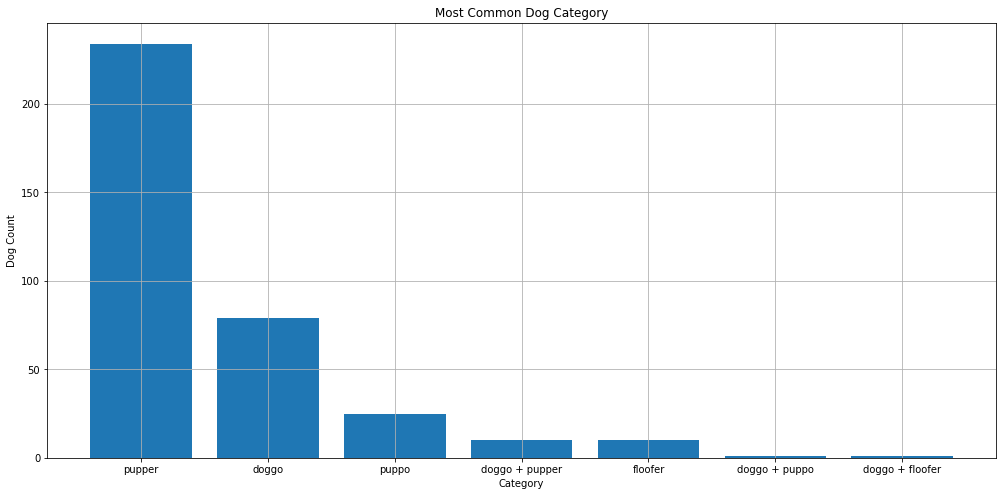

```python
dog_type = ['pupper', 'doggo', 'puppo','doggo + pupper','floofer','doggo + puppo','doggo + floofer']
dog_counts = [234, 79, 25, 10, 10, 1, 1]

fig,ax = plt.subplots(figsize = (17,8))
ax.bar(dog_type, dog_counts, width = 0.8)
ax.set_ylabel('Dog Count')
ax.set_xlabel('Category')
plt.title("Most Common Dog Category")
plt.grid()
plt.show()
```

```python
# Finding which dog is the most popular
master_df.dog_breed_prediction.value_counts()
```

```
golden retriever      141
labrador retriever     97
pembroke               92
chihuahua              87
pug                    57
                     ...
standard schnauzer      1
silky terrier           1
entlebucher             1
scotch terrier          1
groenendael             1
Name: dog_breed_prediction, Length: 111, dtype: int64
```

```python
group1 = master_df.groupby('dog_breed_prediction')['retweet_count'].mean().sort_values(ascending=False)
group1
```

```
dog_breed_prediction
standard poodle           5149.500000
afghan hound              4985.666667
irish water spaniel       4645.250000
english springer          4607.500000
eskimo dog                4375.105263
                             ...
welsh springer spaniel     432.333333
japanese spaniel           378.000000
ibizan hound               357.666667
groenendael                351.000000
brabancon griffon          242.333333
Name: retweet_count, Length: 111, dtype: float64
```

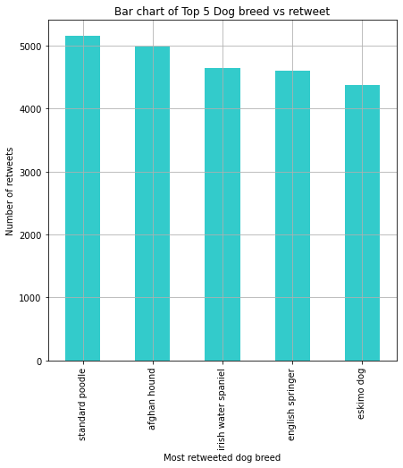

```python
#top 5 most retweeted dog breed
plt.figure(figsize=(7,7))
group1.iloc[:5].plot(kind = 'bar', color = 'c',alpha = 0.8)
plt.xlabel('Most retweeted dog breed')
plt.ylabel('Number of retweets')
plt.title('Bar chart of Top 5 Dog breed vs retweet')
plt.grid()
plt.show()
```

```python
#finding which dog_breed and dog_stage got most retweets
group2 = master_df.groupby(['dog_breed_prediction', 'stage'])['retweet_count'].mean().sort_values(ascending = False)
group2
```

```
dog_breed_prediction   stage
eskimo dog             doggo         55271.0
lakeland terrier       puppo         41823.0
standard poodle        doggo         36024.0
rottweiler             puppo         17031.0
flat-coated retriever  doggopuppo    16733.0
                                      ...
eskimo dog             pupper          391.0
whippet                pupper          358.0
boxer                  pupper          344.0
brabancon griffon      pupper          331.0
bull mastiff           pupper          217.0
Name: retweet_count, Length: 118, dtype: float64
```

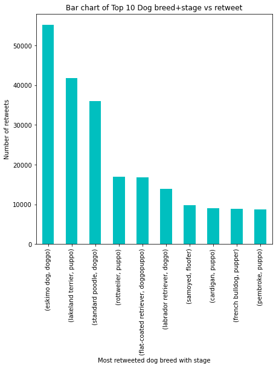

```python
#top 10 most retweeted dog breed
plt.figure(figsize=(7,7))
group2.iloc[:10].plot(kind = 'bar', color = 'c')
plt.xlabel('Most retweeted dog breed with stage')
plt.ylabel('Number of retweets')
plt.title('Bar chart of Top 10 Dog breed+stage vs retweet')
plt.show()
```

## Some Insights

1. Pupper is the most popular dog stage
2. Standard poodle is the dog with most retweets.
3. Eskimo dog of doggo stage is the dog with most retweets.
4. Golden retriever is the dog with the most popularity